# HW 5 Solutions

## Question 1

### (a) (3 pts)

$Y_i \sim NB(\theta, p)$, so $P(Y_i = y) = \dfrac{(y + \theta - 1)!}{y!(\theta - 1)!} (1 - p)^\theta p^y$.

We observe $Y_1,...,Y_n$, so the likelihood is

$L(p) = \prod \limits_{i=1}^n \dfrac{(Y_i + \theta - 1)!}{Y_i!(\theta - 1)!} (1 - p)^\theta p^Y_i$

Thus the log likelihood is

$\ell(p) = \log L(p) = \sum \limits_{i=1}^n \left( \log \left( \dfrac{(Y_i + \theta - 1)!}{Y_i!(\theta - 1)!} \right) + \theta \log(1 - p) + Y_i \log(p) \right)$

**Grading:** They can receive full credit if they use the fact that $\ell(p) = \sum \limits_{i=1}^n \log(P(Y = Y_i))$, correctly substitute in the probability function, and correct apply rules of logs. Additional simplification beyond my solution is possible, but is not required.

### (b) (5 pts)

We take the derivative and set equal to 0:

$\dfrac{d}{dp} \ell(p) = \sum \limits_{i=1}^n \left( -\dfrac{\theta}{1 - p} + \dfrac{Y_i}{p} \right) \overset{set}{=} 0$

So,

$\sum \limits_{i=1}^n \dfrac{Y_i}{p} = \sum \limits_{i=1}^n \dfrac{\theta}{1 - p} = \dfrac{n \theta}{1 - p}$

Rearranging,

$\dfrac{1 - p}{p} = \dfrac{n \theta}{\sum \limits_{i=1}^n Y_i}$

so

$\dfrac{1}{p} = \dfrac{n \theta + \sum \limits_{i=1}^n Y_i}{\sum \limits_{i=1}^n Y_i}$

and thus

$\widehat{p} = \dfrac{\sum \limits_{i=1}^n Y_i}{n\theta + \sum \limits_{i=1}^n Y_i}$

**Grading:** 2 pts for correctly taking the derivative, 1 pt for setting to 0, 2 pts for correctly rearranging and solving for $\widehat{p}$.

## Question 2

### (a) (3 pts)

```r
set.seed(3)
x <- rnorm(100, 0, 1)
p <- exp(-2 + 3*x)/(1 + exp(-2 + 3*x))
y <- rbinom(100, 1, p)
```

**Grading:** 1 pt for generating x, 1 pt for p, 1 pt for y. Note that the coefficients to use for p should be -2 and 3. I have set a seed for the purposes of these solutions, but a seed isn’t necessary for their homework.

### (b) (2 pts)

```r
m1 <- glm(y ~ x, family = binomial)
summary(m1)
```

```
##
## Call:
## glm(formula = y ~ x, family = binomial)
##
## Deviance Residuals:
##     Min       1Q   Median       3Q      Max
## -1.7257  -0.6172  -0.2598   0.6566   2.6821
##
## Coefficients:
##             Estimate Std. Error z value Pr(>|z|)
## (Intercept)  -1.5032     0.3576  -4.203 2.63e-05 ***
## x             2.3303     0.4845   4.809 1.51e-06 ***
## ---
## Signif. codes:  0 '***' 0.001 '**' 0.01 '*' 0.05 '.' 0.1 ' ' 1
##
## (Dispersion parameter for binomial family taken to be 1)
##
##     Null deviance: 122.173  on 99  degrees of freedom
## Residual deviance:  80.121  on 98  degrees of freedom
## AIC: 84.121
##
## Number of Fisher Scoring iterations: 5
```

```r
2.33 - 1.96*0.48
```

```
## [1] 1.3892
```

```r
2.33 + 1.96*0.48
```

```
## [1] 3.2708
```

A 95% confidence interval for $\beta_1$ is (1.39, 3.27). Yes, the interval captures $\beta_1$.

**Grading:** 1 pt for CI, 1 pt for commenting whether it captures $\beta_1$. Lose 1 pt if no code showing. Note that their intervals will be different to mine. Most of them should capture $\beta_1$, but some of them might not.

### (c) (2 pts)

A “95% confidence interval” means that if we collected many sets of data, and created a confidence interval for $\beta_1$ from each dataset, then 95% of them should capture the true $\beta_1$.

### (d) (6 pts)

```r
nsim <- 1000
contains_beta <- rep(0, nsim)
for(i in 1:nsim){
  x <- rnorm(100, 0, 1)
  p <- exp(-2 + 3*x)/(1 + exp(-2 + 3*x))
  y <- rbinom(100, 1, p)

  m1 <- glm(y ~ x, family = binomial)

  upper <- summary(m1)$coefficients[2,1] +
    1.96*summary(m1)$coefficients[2,2]
  lower <- summary(m1)$coefficients[2,1] -
    1.96*summary(m1)$coefficients[2,2]

  contains_beta[i] <- upper > 3 && lower < 3
}
mean(contains_beta)
```

```
## [1] 0.957
```

In this simulation, 95.7% of the intervals contained $\beta_1$, which is close to the expected fraction of 95%.

**Grading:**

- 1 pt for simulating new data at each iteration.
- 1 pt for fitting a model at each iteration.
- 1 pt for correctly calculating the upper and lower endpoints at each iteration.
- 1 pt for storing the result (whether the interval contains $\beta_1$) at each iteration.
- 1 pt for calculating the fraction of intervals which contained $\beta_1$
- 1 pt for the expected fraction of intervals containing $\beta_1$ (95%)

No credit if code is not shown! Lose 3 pts if they add outliers to this part of the assignment.

### (e) (2 pts)

```r
nsim <- 1000
contains_beta <- rep(0, nsim)
for(i in 1:nsim){
  x <- rnorm(100, 0, 1)
  p <- exp(-2 + 3*x)/(1 + exp(-2 + 3*x))
  y <- rbinom(100, 1, p)

  m1 <- glm(y ~ x, family = binomial)

  upper <- summary(m1)$coefficients[2,1] +
    qnorm(0.005, lower.tail=F)*summary(m1)$coefficients[2,2]
  lower <- summary(m1)$coefficients[2,1] -
    qnorm(0.005, lower.tail=F)*summary(m1)$coefficients[2,2]

  contains_beta[i] <- upper > 3 && lower < 3
}
mean(contains_beta)
```

```
## [1] 0.991
```

Our observed coverage probability is indeed close to the expected coverage probability of 99%.

**Grading:** No points if no code is shown. No credit if they don’t change the critical value to the correct value (`qnorm(0.005, lower.tail=F)` is approximately 2.58)

## Question 3

### (a) (4 pts)

```r
nsim <- 1000
contains_beta <- rep(0, nsim)
for(i in 1:nsim){
  x <- rnorm(100, 0, 1)
  p <- exp(-2 + 3*x)/(1 + exp(-2 + 3*x))
  y <- rbinom(100, 1, p)

  x1 <- c(x, -2)
  y1 <- c(y, 1)

  m1 <- glm(y1 ~ x1, family = binomial)

  upper <- summary(m1)$coefficients[2,1] +
    1.96*summary(m1)$coefficients[2,2]
  lower <- summary(m1)$coefficients[2,1] -
    1.96*summary(m1)$coefficients[2,2]

  contains_beta[i] <- upper > 3 && lower < 3
}
mean(contains_beta)
```

```
## [1] 0.718
```

Our coverage probability has decreased substantially with the outlier, which are affecting our estimated coefficients.

**Grading:** Lose 2 pts if the outlier is not at the appropriate place (-2, 1). Lose 1 pt if they don’t fit the model with the new data containing the outlier. Lose 1 pt if they don’t interpret the results. No credit if code is not shown.

### (b) (8 pts)

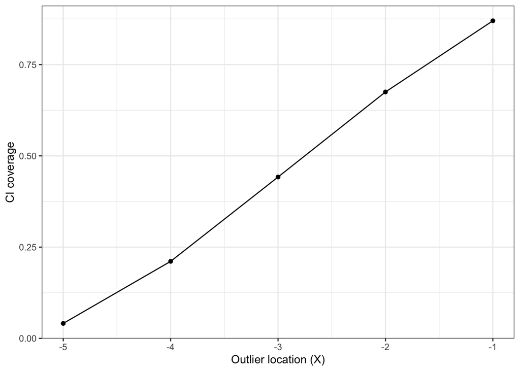

```r
nsim <- 1000
xlocs <- c(-1, -2, -3, -4, -5)
coverage <- rep(0, length(xlocs))

for(j in 1:length(xlocs)){
  contains_beta <- rep(0, nsim)
  for(i in 1:nsim){
    x <- rnorm(100, 0, 1)
    p <- exp(-2 + 3*x)/(1 + exp(-2 + 3*x))
    y <- rbinom(100, 1, p)

    x1 <- c(x, xlocs[j])
    y1 <- c(y, 1)

    m1 <- glm(y1 ~ x1, family = binomial)

    upper <- summary(m1)$coefficients[2,1] +
      1.96*summary(m1)$coefficients[2,2]
    lower <- summary(m1)$coefficients[2,1] -
      1.96*summary(m1)$coefficients[2,2]

    contains_beta[i] <- upper > 3 && lower < 3
  }
  coverage[j] <- mean(contains_beta)
}

data.frame(x = xlocs, coverage = coverage) %>%
  ggplot(aes(x = x, y = coverage)) +
  geom_point() +
  geom_line() +
  labs(x = "Outlier location (X)", y = "CI coverage") +
  theme_bw()
```

As we can see in the plot, coverage of the confidence intervals decreases as the outlier becomes more extreme in X.

**Grading:** 3 pts for calculating the coverage probabilities, 3 pts for making the plot, 2 pts for their conclusion about outliers and coverage probabilities. No credit if no code is shown. I have written the code using a second for loop over the outlier locations, but this is not necessary.

## Question 4 (Extra credit)

This is an extra credit section. They can earn one point of extra credit for each correct answer.

### (a) (1 pt)

The error says that sqrtFare is not found. This occurs because we never saved this new column in the titanic data.

### (b) (1 pt)

We can fix the error by saving the sqrtFare column in the titanic data. For example:

```r
titanic <- titanic %>%
  mutate(sqrtFare = sqrt(Fare))
```